# R Notebook

## Modeling

Lets try to fit simple model

```r
rm(list = ls())
library(brms)
library(tidybayes)
library(tidyverse)
library(here)
```

```r
d <- read_rds(here("raw data", "clean_dat.rds"))
```

Lets start with the linear model just with intercepts for each smile type Obviously linear model is not perfectly suitable because of the type of response variable. For example, the distance between 0 and 1 might be different with the 5 and 6 for.

### Intercept model

```r
m.1 <-
  brm(data = d,
      family = gaussian,
      cand_competency ~ 0 + cand_smile,   # 0 indicates that there is separate intercept
                                          # for each smile type
      prior = c(prior(normal(0.5, 0.25), class = b),
                prior(exponential(1), class = sigma)),
      iter = 2000, warmup = 1000, chains = 4, cores = 4,
      seed = 1,
      file = "fits/m.1")
```

```r
print(m.1)
```

```
 Family: gaussian
  Links: mu = identity; sigma = identity
Formula: cand_competency ~ 0 + cand_smile
   Data: d (Number of observations: 3768)
Samples: 4 chains, each with iter = 2000; warmup = 1000; thin = 1;
         total post-warmup samples = 4000

Population-Level Effects:
                Estimate Est.Error l-95% CI u-95% CI Rhat Bulk_ESS Tail_ESS
cand_smileno        0.68      0.01     0.67     0.69 1.00     3489     2581
cand_smilesmall     0.70      0.01     0.69     0.71 1.00     4051     2756
cand_smilebig       0.66      0.01     0.65     0.68 1.00     4693     3062

Family Specific Parameters:
      Estimate Est.Error l-95% CI u-95% CI Rhat Bulk_ESS Tail_ESS
sigma     0.20      0.00     0.19     0.20 1.00     3629     3081

Samples were drawn using sampling(NUTS). For each parameter, Bulk_ESS
and Tail_ESS are effective sample size measures, and Rhat is the potential
scale reduction factor on split chains (at convergence, Rhat = 1).
```

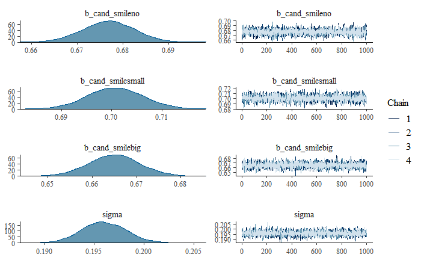

```r
plot(m.1)
```

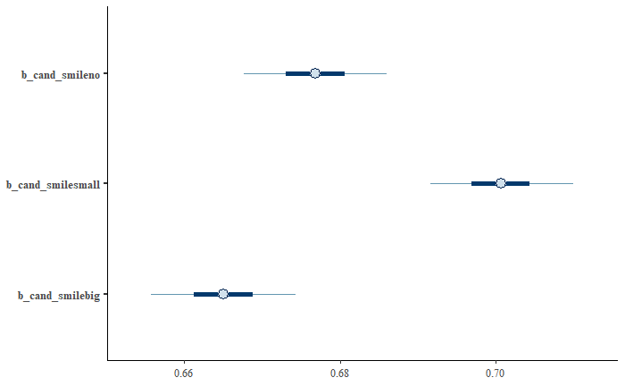

```r
mcmc_plot(m.1, pars = "b_")
```

The result resemble the one in the blogpost. Candidates with small smile look slightly more competent

```r
m.2 <-
  brm(data = d,
      family = gaussian,
      cand_competency ~ 0 + cand_smile + # separate intercept for each smile type
        (1 | cand_id),                   # varying intercept by candidates
      prior = c(prior(normal(0.5, 0.25), class = b),
                prior(exponential(1), class = sigma)),
      iter = 2000, warmup = 1000, chains = 4, cores = 4,
      seed = 1,
      file = "fits/m.2")
```

model took 10 seconds to estimate

```r
print(m.2)
```

```
 Family: gaussian
  Links: mu = identity; sigma = identity
Formula: cand_competency ~ 0 + cand_smile + (1 | cand_id)
   Data: d (Number of observations: 3768)
Samples: 4 chains, each with iter = 2000; warmup = 1000; thin = 1;
         total post-warmup samples = 4000

Group-Level Effects:
~cand_id (Number of levels: 12)
              Estimate Est.Error l-95% CI u-95% CI Rhat Bulk_ESS Tail_ESS
sd(Intercept)     0.06      0.02     0.03     0.10 1.01      594      942

Population-Level Effects:
                Estimate Est.Error l-95% CI u-95% CI Rhat Bulk_ESS Tail_ESS
cand_smileno        0.67      0.02     0.64     0.71 1.00      565      728
cand_smilesmall     0.70      0.02     0.66     0.73 1.00      566      711
cand_smilebig       0.66      0.02     0.62     0.69 1.00      565      725

Family Specific Parameters:
      Estimate Est.Error l-95% CI u-95% CI Rhat Bulk_ESS Tail_ESS
sigma     0.19      0.00     0.19     0.19 1.00     2782     2509

Samples were drawn using sampling(NUTS). For each parameter, Bulk_ESS
and Tail_ESS are effective sample size measures, and Rhat is the potential
scale reduction factor on split chains (at convergence, Rhat = 1).
```

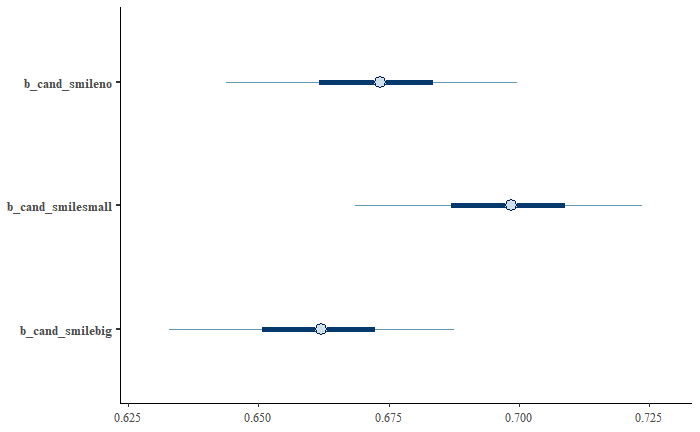

```r
mcmc_plot(m.2, pars = "b_")
```

### Varying slopes and intercepts

Lets try to add slopes varying by sex to intercepts

```r
m.3 <-
  brm(data = d,
      family = gaussian,
      cand_competency ~ 0 + cand_smile + # separate intercept for each smile type
        (1 + cand_sex || cand_id),        # uncorrelated random slope and intercept
      prior = c(prior(normal(0.5, 0.25), class = b),
                prior(exponential(1), class = sigma)),
      iter = 3000, warmup = 1000, chains = 4, cores = 4,
      control = list(adapt_delta = 0.98),
      seed = 3,
      file = "fits/m.3")
```

```r
print(m.3)
```

```
There were 3 divergent transitions after warmup. Increasing adapt_delta above 0.98 may help. See http://mc-stan.org/misc/warnings.html#divergent-transitions-after-warmup
```

```
 Family: gaussian
  Links: mu = identity; sigma = identity
Formula: cand_competency ~ 0 + cand_smile + (1 + cand_sex || cand_id)
   Data: d (Number of observations: 3768)
Samples: 4 chains, each with iter = 3000; warmup = 1000; thin = 1;
         total post-warmup samples = 8000

Group-Level Effects:
~cand_id (Number of levels: 12)
              Estimate Est.Error l-95% CI u-95% CI Rhat Bulk_ESS Tail_ESS
sd(Intercept)     0.06      0.02     0.03     0.10 1.00     2689     4173
sd(cand_sexM)     0.05      0.04     0.00     0.16 1.00     2006     3651

Population-Level Effects:
                Estimate Est.Error l-95% CI u-95% CI Rhat Bulk_ESS Tail_ESS
cand_smileno        0.67      0.02     0.63     0.71 1.00     1893     2901
cand_smilesmall     0.69      0.02     0.65     0.73 1.00     1908     3157
cand_smilebig       0.66      0.02     0.62     0.69 1.00     1882     3094

Family Specific Parameters:
      Estimate Est.Error l-95% CI u-95% CI Rhat Bulk_ESS Tail_ESS
sigma     0.19      0.00     0.19     0.19 1.00    12107     5627

Samples were drawn using sampling(NUTS). For each parameter, Bulk_ESS
and Tail_ESS are effective sample size measures, and Rhat is the potential
scale reduction factor on split chains (at convergence, Rhat = 1).
```

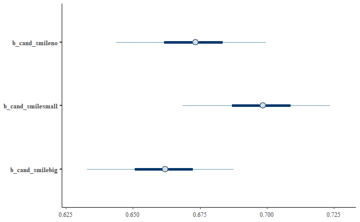

```r
mcmc_plot(m.2, pars = "b_")
```

The estimates are quite the same as in 2nd model

Just for the sake of and experiment I will try an alternative model specification

```r
m.4 <-
  brm(data = d,
      family = gaussian,
      cand_competency ~ 0 + cand_smile + cand_sex:resp_sex + (1 | cand_id),
      prior = c(prior(normal(0, 1), class = b),
                prior(exponential(1), class = sigma)),
      control = list(adapt_delta = 0.98),
      iter = 4000, warmup = 2000, chains = 4, cores = 4,
      seed = 4,
      file = "fits/m.4")
```

```r
print(m.4)
```

```
 Family: gaussian
  Links: mu = identity; sigma = identity
Formula: cand_competency ~ 0 + cand_smile + cand_sex:resp_sex + (1 | cand_id)
   Data: d (Number of observations: 3768)
Samples: 4 chains, each with iter = 4000; warmup = 2000; thin = 1;
         total post-warmup samples = 8000

Group-Level Effects:
~cand_id (Number of levels: 12)
              Estimate Est.Error l-95% CI u-95% CI Rhat Bulk_ESS Tail_ESS
sd(Intercept)     0.05      0.01     0.03     0.09 1.00     1755     3018

Population-Level Effects:
                    Estimate Est.Error l-95% CI u-95% CI Rhat Bulk_ESS Tail_ESS
cand_smileno            0.40      0.38    -0.35     1.16 1.00     1588     2292
cand_smilesmall         0.43      0.38    -0.32     1.20 1.00     1587     2353
cand_smilebig           0.39      0.38    -0.36     1.16 1.00     1587     2296
cand_sexF:resp_sexF     0.29      0.38    -0.47     1.04 1.00     1593     2366
cand_sexM:resp_sexF     0.31      0.38    -0.45     1.07 1.00     1583     2303
cand_sexF:resp_sexM     0.23      0.38    -0.53     0.98 1.00     1594     2365
cand_sexM:resp_sexM     0.29      0.38    -0.47     1.04 1.00     1583     2272

Family Specific Parameters:
      Estimate Est.Error l-95% CI u-95% CI Rhat Bulk_ESS Tail_ESS
sigma     0.19      0.00     0.18     0.19 1.00     6033     4870

Samples were drawn using sampling(NUTS). For each parameter, Bulk_ESS
and Tail_ESS are effective sample size measures, and Rhat is the potential
scale reduction factor on split chains (at convergence, Rhat = 1).
```

This est. errors looks huge. Seems that is because of the multicolinearity

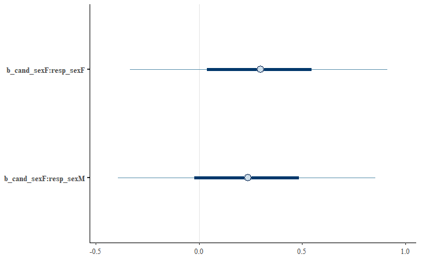

```r
mcmc_plot(m.4, pars = "cand_sexF")
```

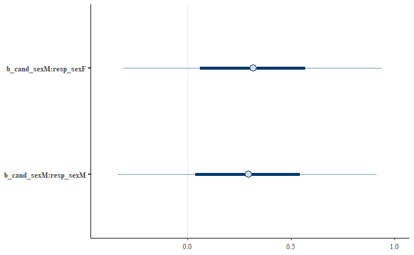

```r
mcmc_plot(m.4, pars = "cand_sexM")
```

### Compare models

```r
m.1 <- add_criterion(m.1, criterion = "loo")
m.2 <- add_criterion(m.2, criterion = "loo")
m.3 <- add_criterion(m.3, criterion = "loo")
m.4 <- add_criterion(m.4, criterion = "loo")
```

```r
loo_compare(m.1, m.2, m.3, m.4, criterion = "loo") %>%
  print(simplify = F)
```

```
    elpd_diff se_diff elpd_loo se_elpd_loo p_loo   se_p_loo looic   se_looic
m.4     0.0       0.0   929.5     42.9        16.6     0.4  -1859.1    85.8
m.3   -27.9       7.7   901.7     42.8        14.5     0.4  -1803.3    85.7
m.2   -28.1       7.7   901.5     42.8        14.7     0.4  -1802.9    85.6
m.1  -135.8      16.7   793.7     41.0         3.9     0.1  -1587.4    81.9
```

As expected, the simplest first model performs much worse There is no much of a difference between second and third model Fourth performs slightly better then others, but it suffers from multicollinearity

## model with all the data

```r
get_prior(data = d,
      family = gaussian,
      cand_competency ~ 0 + cand_smile + cand_sex + (1 | cand_id) +
        resp_sex + resp_hire)
```

```
                prior class               coef   group resp dpar nlpar bound
               (flat)     b
               (flat)     b          cand_sexM
               (flat)     b      cand_smilebig
               (flat)     b       cand_smileno
               (flat)     b    cand_smilesmall
               (flat)     b    resp_hirealways
               (flat)     b resp_hiresometimes
               (flat)     b          resp_sexM
 student_t(3, 0, 2.5)    sd
 student_t(3, 0, 2.5)    sd                    cand_id
 student_t(3, 0, 2.5)    sd          Intercept cand_id
 student_t(3, 0, 2.5) sigma
       source
      default
 (vectorized)
 (vectorized)
 (vectorized)
 (vectorized)
 (vectorized)
 (vectorized)
 (vectorized)
      default
 (vectorized)
 (vectorized)
      default
```

```r
m.5 <-
  brm(data = d,
      family = gaussian,
      cand_competency ~ 0 + cand_smile + cand_sex +
         resp_sex + resp_hire + (1 | cand_id),
      prior = c(prior(normal(0, 0.5), class = b),
                prior(exponential(1), class = sigma)),
      iter = 4000, warmup = 2000, chains = 4, cores = 4,
      seed = 4,
      file = "fits/m.5")
```

```r
print(m.5)
```

```
 Family: gaussian
  Links: mu = identity; sigma = identity
Formula: cand_competency ~ 0 + cand_smile + cand_sex + (1 | cand_id) + resp_sex + resp_hire
   Data: d (Number of observations: 3768)
Samples: 4 chains, each with iter = 4000; warmup = 2000; thin = 1;
         total post-warmup samples = 8000

Group-Level Effects:
~cand_id (Number of levels: 12)
              Estimate Est.Error l-95% CI u-95% CI Rhat Bulk_ESS Tail_ESS
sd(Intercept)     0.05      0.02     0.03     0.09 1.00     1921     2474

Population-Level Effects:
                   Estimate Est.Error l-95% CI u-95% CI Rhat Bulk_ESS Tail_ESS
cand_smileno           0.68      0.02     0.63     0.72 1.00     1840     2146
cand_smilesmall        0.70      0.02     0.66     0.75 1.00     1832     2207
cand_smilebig          0.67      0.02     0.62     0.71 1.00     1820     2276
cand_sexM              0.05      0.03    -0.01     0.12 1.00     2088     2685
resp_sexM             -0.05      0.01    -0.06    -0.03 1.00     7490     5532
resp_hiresometimes     0.00      0.01    -0.01     0.02 1.00     6594     5932
resp_hirealways        0.02      0.01    -0.00     0.03 1.00     6883     5631

Family Specific Parameters:
      Estimate Est.Error l-95% CI u-95% CI Rhat Bulk_ESS Tail_ESS
sigma     0.19      0.00     0.18     0.19 1.00     7853     5760

Samples were drawn using sampling(NUTS). For each parameter, Bulk_ESS
and Tail_ESS are effective sample size measures, and Rhat is the potential
scale reduction factor on split chains (at convergence, Rhat = 1).
```

This seem much better than 4th model. Standard errors are much narrower.

```r
m.5 <- add_criterion(m.5, criterion = "loo")
```

```r
loo_compare(m.2, m.4, m.5, criterion = "loo") %>%
  print(simplify = F)
```

```
    elpd_diff se_diff elpd_loo se_elpd_loo p_loo   se_p_loo looic   se_looic
m.4     0.0       0.0   929.5     42.9        16.6     0.4  -1859.1    85.8
m.5    -2.8       3.5   926.7     42.9        17.5     0.4  -1853.4    85.8
m.2   -28.1       7.7   901.5     42.8        14.7     0.4  -1802.9    85.6
```

# Cummulative link Model

As I wrote treating ordered categorical outcome as a continuous variable generally is not the best idea. Lets do it in a proper way

```r
m.6 <-
  brm(data = d,
      family = cumulative,
      cand_competency_fct ~ 1 + cand_smile,
      prior = c(prior(normal(0, 1.5), class = Intercept),
                prior(normal(0, 0.5), class = b)),
      iter = 2000, warmup = 1000, cores = 4, chains = 4,
      seed = 12,
      file = "fits/m.6")
```

```r
print(m.6)
```

```
 Family: cumulative
  Links: mu = logit; disc = identity
Formula: cand_competency_fct ~ 1 + cand_smile
   Data: d (Number of observations: 3768)
Samples: 4 chains, each with iter = 2000; warmup = 1000; thin = 1;
         total post-warmup samples = 4000

Population-Level Effects:
                Estimate Est.Error l-95% CI u-95% CI Rhat Bulk_ESS Tail_ESS
Intercept[1]       -4.07      0.13    -4.34    -3.81 1.00     2078     2393
Intercept[2]       -2.82      0.08    -2.99    -2.67 1.00     2950     2955
Intercept[3]       -1.57      0.06    -1.69    -1.45 1.00     3157     2718
Intercept[4]       -0.30      0.05    -0.40    -0.20 1.00     3282     2899
Intercept[5]        0.86      0.05     0.76     0.97 1.00     3295     2679
Intercept[6]        2.10      0.07     1.97     2.23 1.00     3389     2740
cand_smilesmall     0.22      0.07     0.08     0.36 1.00     3229     2507
cand_smilebig      -0.11      0.07    -0.25     0.03 1.00     3025     2558

Family Specific Parameters:
     Estimate Est.Error l-95% CI u-95% CI Rhat Bulk_ESS Tail_ESS
disc     1.00      0.00     1.00     1.00 1.00     4000     4000

Samples were drawn using sampling(NUTS). For each parameter, Bulk_ESS
and Tail_ESS are effective sample size measures, and Rhat is the potential
scale reduction factor on split chains (at convergence, Rhat = 1).
```

```r
m.7 <-
  brm(data = d,
      family = cumulative,
      cand_competency_fct ~ 1 + cand_smile + cand_sex + (1 | cand_id),
      prior = c(prior(normal(0, 2), class = Intercept),
                prior(normal(0, 0.5), class = b)),
      iter = 2000, warmup = 1000, cores = 4, chains = 4,
      seed = 12,
      file = "fits/m.7")
```

```r
print(m.7)
```

```
 Family: cumulative
  Links: mu = logit; disc = identity
Formula: cand_competency_fct ~ 1 + cand_smile + cand_sex + (1 | cand_id)
   Data: d (Number of observations: 3768)
Samples: 4 chains, each with iter = 2000; warmup = 1000; thin = 1;
         total post-warmup samples = 4000

Group-Level Effects:
~cand_id (Number of levels: 12)
              Estimate Est.Error l-95% CI u-95% CI Rhat Bulk_ESS Tail_ESS
sd(Intercept)     0.51      0.14     0.31     0.86 1.00      997     1514

Population-Level Effects:
                Estimate Est.Error l-95% CI u-95% CI Rhat Bulk_ESS Tail_ESS
Intercept[1]       -4.03      0.23    -4.47    -3.59 1.00     1657     2257
Intercept[2]       -2.76      0.20    -3.17    -2.38 1.00     1590     2124
Intercept[3]       -1.47      0.19    -1.85    -1.09 1.00     1530     2135
Intercept[4]       -0.14      0.19    -0.51     0.24 1.00     1453     2155
Intercept[5]        1.09      0.19     0.71     1.47 1.00     1480     1976
Intercept[6]        2.36      0.20     1.97     2.73 1.00     1480     2312
cand_smilesmall     0.23      0.07     0.09     0.36 1.00     3766     2722
cand_smilebig      -0.11      0.07    -0.25     0.02 1.00     4039     3135
cand_sexM           0.33      0.26    -0.19     0.84 1.00     1655     2019

Family Specific Parameters:
     Estimate Est.Error l-95% CI u-95% CI Rhat Bulk_ESS Tail_ESS
disc     1.00      0.00     1.00     1.00 1.00     4000     4000

Samples were drawn using sampling(NUTS). For each parameter, Bulk_ESS
and Tail_ESS are effective sample size measures, and Rhat is the potential
scale reduction factor on split chains (at convergence, Rhat = 1).
```

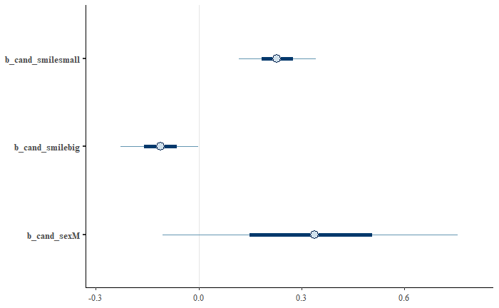

```r
mcmc_plot(m.7, pars = "b_cand")
```

```r
m.8 <-
  brm(data = d,
      family = cumulative,
      cand_competency_fct ~ 1 + cand_smile + cand_sex + resp_sex + resp_hire +
        (1 | cand_id),
      prior = c(prior(normal(0, 2), class = Intercept),
                prior(normal(0, 0.5), class = b)),
      iter = 2000, warmup = 1000, cores = 4, chains = 4,
      seed = 12,
      file = "fits/m.8")
```

```r
print(m.8)
```

```
 Family: cumulative
  Links: mu = logit; disc = identity
Formula: cand_competency_fct ~ 1 + cand_smile + cand_sex + resp_sex + resp_hire + (1 | cand_id)
   Data: d (Number of observations: 3768)
Samples: 4 chains, each with iter = 2000; warmup = 1000; thin = 1;
         total post-warmup samples = 4000

Group-Level Effects:
~cand_id (Number of levels: 12)
              Estimate Est.Error l-95% CI u-95% CI Rhat Bulk_ESS Tail_ESS
sd(Intercept)     0.52      0.15     0.32     0.90 1.00     1068     1959

Population-Level Effects:
                   Estimate Est.Error l-95% CI u-95% CI Rhat Bulk_ESS Tail_ESS
Intercept[1]          -4.30      0.23    -4.77    -3.86 1.00     1709     2219
Intercept[2]          -3.04      0.21    -3.44    -2.62 1.00     1575     2138
Intercept[3]          -1.74      0.20    -2.13    -1.35 1.00     1515     1995
Intercept[4]          -0.39      0.20    -0.78    -0.01 1.00     1464     2154
Intercept[5]           0.85      0.20     0.45     1.23 1.00     1453     2049
Intercept[6]           2.12      0.20     1.72     2.52 1.00     1511     2116
cand_smilesmall        0.24      0.07     0.11     0.38 1.00     4578     2964
cand_smilebig         -0.10      0.07    -0.24     0.04 1.00     4676     3031
cand_sexM              0.32      0.26    -0.23     0.81 1.00     1167     1857
resp_sexM             -0.43      0.06    -0.54    -0.31 1.00     5075     3148
resp_hiresometimes    -0.05      0.07    -0.17     0.08 1.00     4632     2857
resp_hirealways        0.08      0.08    -0.07     0.24 1.00     4507     2944

Family Specific Parameters:
     Estimate Est.Error l-95% CI u-95% CI Rhat Bulk_ESS Tail_ESS
disc     1.00      0.00     1.00     1.00 1.00     4000     4000

Samples were drawn using sampling(NUTS). For each parameter, Bulk_ESS
and Tail_ESS are effective sample size measures, and Rhat is the potential
scale reduction factor on split chains (at convergence, Rhat = 1).
```

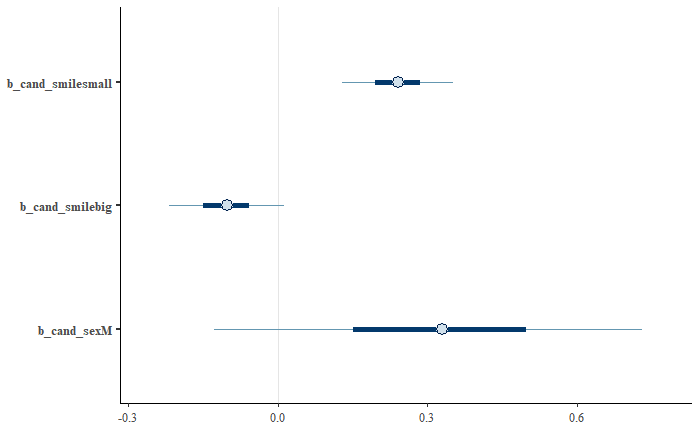

```r
mcmc_plot(m.8, pars = "b_cand")
```

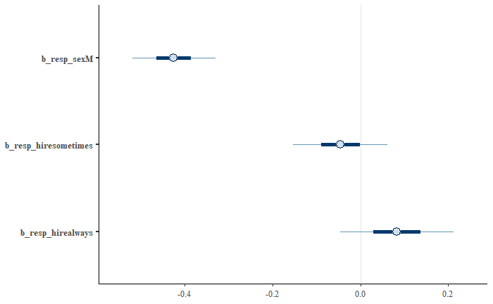

```r
mcmc_plot(m.8, pars = "b_resp")
```

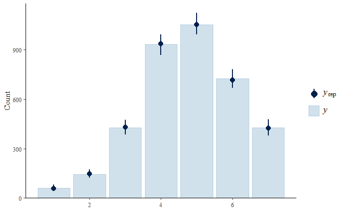

```r
pp_check(m.8, type = "bars", nsamples = 100)
```

Quick model comparison

```r
m.6 <- add_criterion(m.6, criterion = "loo")
```

```
Automatically saving the model object in 'fits/m.6.rds'
```

```r
m.7 <- add_criterion(m.7, criterion = "loo")
```

```
Automatically saving the model object in 'fits/m.7.rds'
```

```r
m.8 <- add_criterion(m.8, criterion = "loo")
```

```
Automatically saving the model object in 'fits/m.8.rds'
```

```r
loo_compare(m.6, m.7, m.8, criterion = "loo") %>%
  print(simplify = F)
```

```
    elpd_diff se_diff elpd_loo se_elpd_loo p_loo   se_p_loo looic   se_looic
m.8     0.0       0.0 -6273.0     36.9        21.3     0.3  12545.9    73.8
m.7   -24.7       7.2 -6297.7     36.6        18.4     0.3  12595.4    73.1
m.6  -140.3      16.7 -6413.2     34.4         8.0     0.2  12826.5    68.9
```

As expected, 8th model performs the best